# Project AAPL

Xingyi Andrew, Si Miao and Zhiyuan Ren

4/22/2020

# Load Libraries

```r
library("fImport")
library(RQuantLib)
library(nlstools)
library(tseries)
library(Quandl)
library(zoo)
library(PerformanceAnalytics)
library(quantmod)
library(FinTS)
library(forecast)
require(stats)
#library(stockPortfolio)
library(vars)
library(tseries, quietly = T)
library(forecast, quietly = T)
library(fBasics)
library(timsac)
library(TTR)
library(lattice)
library(foreign)
library(MASS)
require(stats4)
library(KernSmooth)
library(fastICA)
library(cluster)
library(leaps)
library(mgcv)
```

```r
library(rpart)
require("datasets")
require(graphics)
library(RColorBrewer)
library(lattice)
library(foreign)
library(KernSmooth)
library(mgcv)
library(DAAG)
library("TTR")
library(tis)
library("forecast")
require(astsa)
library(seasonal)
library(fpp2)
library(ggplot2)
library(fma)
library(seasonal)
```

## I. Introduction

Modelling and forecasting stock price is a popular and key issue for investors as well as researchers in the financial markets. In this project, our selected data is AAPL monthly adjsuted close prices from 2015 Janurary to 2019 December, which consists of 5-year stock data from Apple Inc.. We choose this stock mainly because we are interesting in AAPL stock performance and would like to fit a model and forecast AAPL monthly adjsuted close prices. Our data is in the form of historical stock prices. In this project, for the first part, we will conduct research and find a fit model and use this model to forecast the monthly AAPL adjusted close prices 25-steps ahead. In the second part, we will construct a model with a full set of seasonal dunmmies. Then, we will add some trends to improve the seasonal model. We will use this final model to forecast AAPL monthly adjusted close price for next 25 steps (months).

## II. Results (answers and plots)

First, we show a time-series plot of your data.

```r
#get the monthly data we need
getSymbols("AAPL", from = "2015-01-01", to = "2019-12-31",
           periodicity = "monthly", curl.options = list())
```

[output not shown]

```
## [1] "AAPL"
```

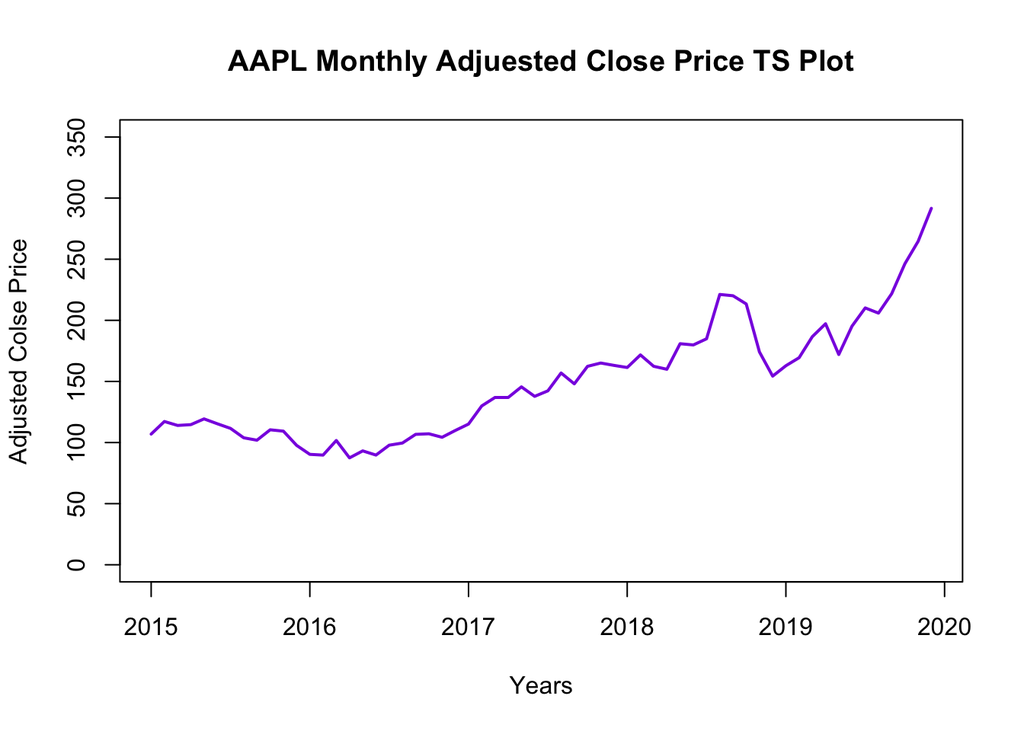

```r
#create a time series object
adj.close <- ts(AAPL$AAPL.Adjusted, start = 2015, frequency = 12)
#plot the time-series plot
plot(adj.close, main="AAPL Monthly Adjuested Close Price TS Plot",
     xlab="Years", ylab = "Adjusted Colse Price",
     col  = "blueviolet", ylim = c(0, 350), lwd = 2)
```

Then we plot the time-series of data with mean.

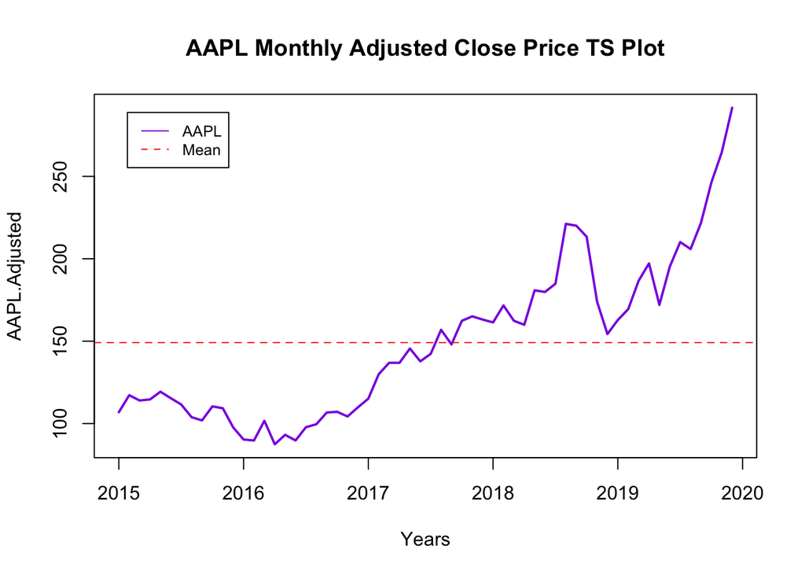

```r
#plot the time-series of data with mean
plot(adj.close,main="AAPL Monthly Adjusted Close Price TS Plot",
     xlab="Years", col  = "blueviolet", lwd = 2)
#add the mean line
abline(h = mean(adj.close), col='red',lty=2)
#add the legend to the plot
legend("topleft", inset = 0.05, legend=c("AAPL", "Mean"),
       col = c("blueviolet", "red"), cex = 0.8, lty=1:2)
```

The graph shows the time series has an upward trend and does not have mean-reversion. The data do not have constant mean and stable variance, which suggest that the data are not covariance stationary.

We will plot ACF and PACF of AAPL Monthly Adjusted Close Prices.

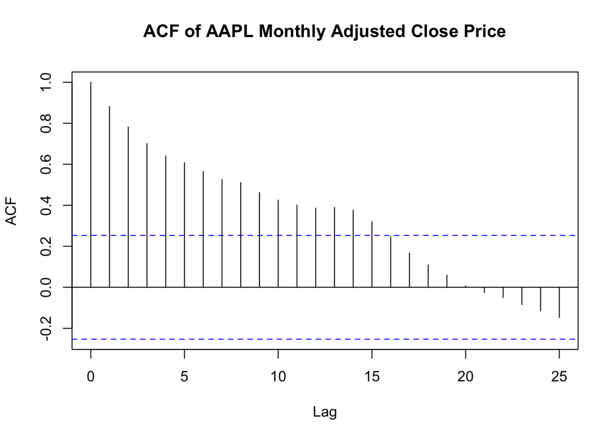

```r
#plot the ACF of data
acf(AAPL$AAPL.Adjusted, main = "ACF of AAPL Monthly Adjusted Close Price",
    lag.max = 25)
```

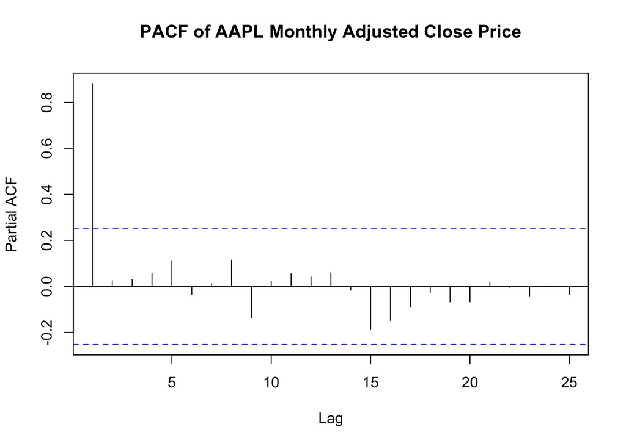

```r
#plot the PACF of data
pacf(AAPL$AAPL.Adjusted, main = "PACF of AAPL Monthly Adjusted Close Price",
     lag.max = 25)
```

We find that in the ACF of the AAPL monthly adjusted close price, there exists a decay in the autocorrelation function, indicating non-stationarity of the data. Since the first 16 lags in ACF are beyond the range(the blue dash line), then these lags are significant, which means that the AAPL monthly adjusted close prices are correlated for the first 16 lags. For PACF, there exists a decay and a large spike of the first lag in the partial autocorrelation function.

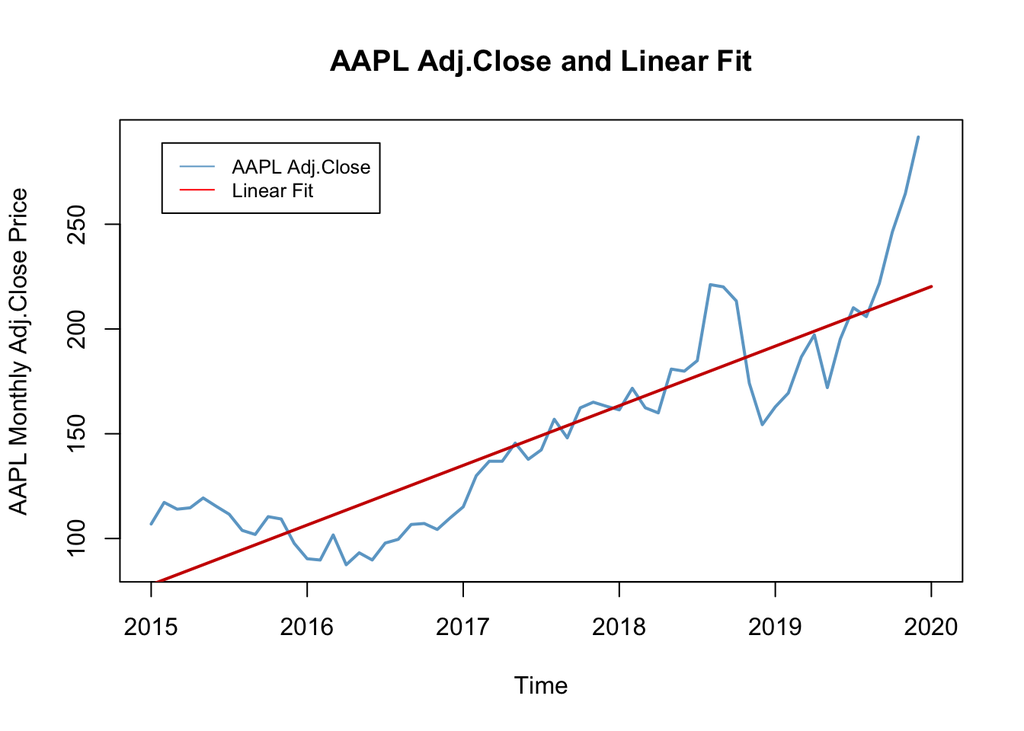

```r
# Linear Fit
# create an object to store time variable
t = seq(2015, 2020,length=length(adj.close))
# construct linear fit of the data
m1 = lm(adj.close ~ t)
# plot the original time series
plot(adj.close, ylab = "AAPL Monthly Adj.Close Price", xlab="Time",
     lwd=2, col='skyblue3', xlim=c(2015, 2020),
     main = "AAPL Adj.Close and Linear Fit")
# add the fit values of the linear model
lines(t,m1$fit, col="red3", lwd=2)
#add the legend to the plot
legend("topleft", inset = 0.05, legend=c("AAPL Adj.Close", "Linear Fit"),
       col = c("skyblue3", "red"), cex = 0.8, lty=1:1)
```

Second, we fit a non-linear model to the series.

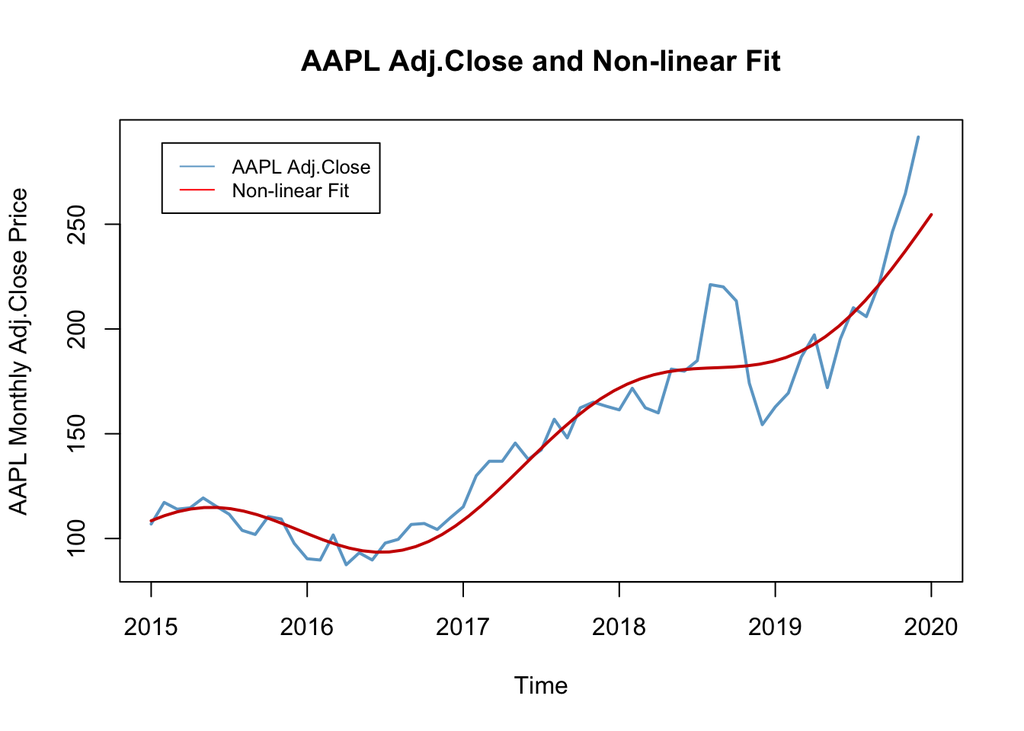

```r
# Non-Linear Fit
# construct non-linear fit of the data
m2 = lm(adj.close ~  sin((3/4)*pi*t) + t + I(t^2))
# plot the original time series
plot(adj.close,ylab = "AAPL Monthly Adj.Close Price",
     xlab="Time", lwd=2, col='skyblue3', xlim=c(2015, 2020),
     main = "AAPL Adj.Close and Non-linear Fit")
# add the fit values of the non-linear model
lines(t,m2$fit,col="red3",lwd=2)
#add the legend to the plot
legend("topleft", inset = 0.05, legend=c("AAPL Adj.Close", "Non-linear Fit"),
       col = c("skyblue3", "red"), cex = 0.8, lty=1:1)
```

First, plot the residuals and fitted values of the linear model.

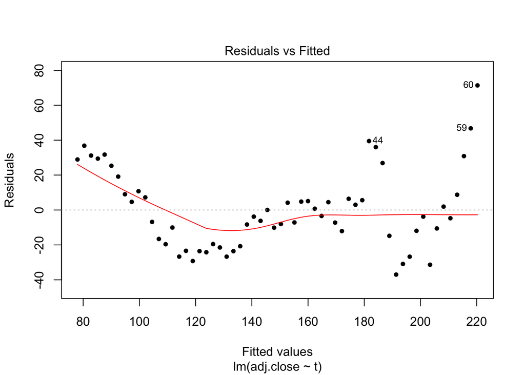

```r
#plot the residuals and fitted values of the non-linear model
plot(m1, 1, pch = 20)
```

Second, plot the residuals and fitted values of the non-linear model.

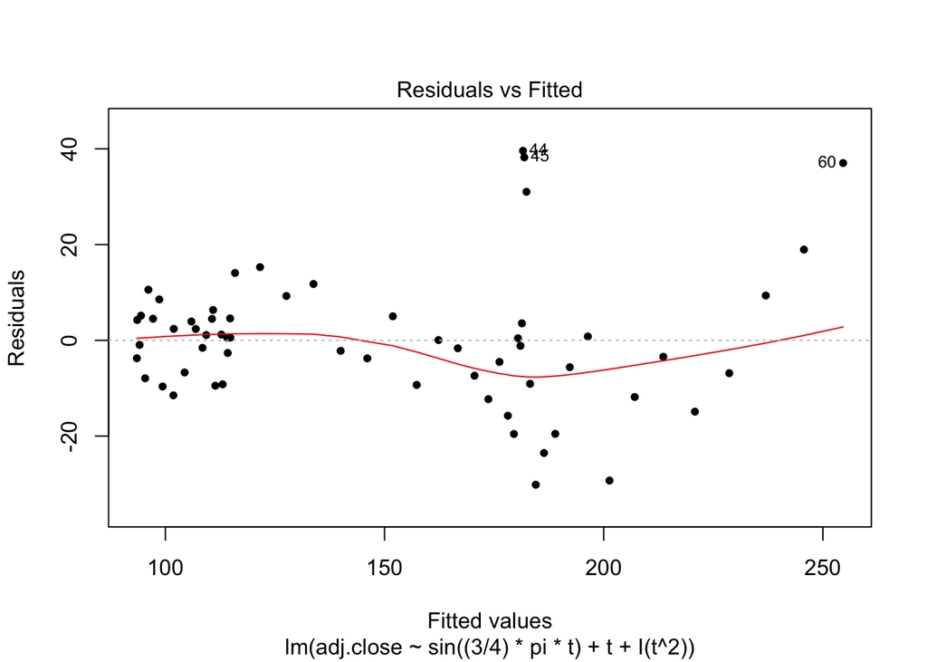

```r
#plot the residuals and fitted values of the non-linear model
plot(m2, 1, pch = 20)
```

From the Residual vs Fitted plot, we can see that linearity seems to hold reasonably well, as the red line is close to the dashed zero line. The residuals bounce randomly around the 0 and there is non-linear relationship between fitted values and residuals, suggesting that this model is reasonable. The residuals of the log-linear model is more stable and much smaller compared to the residual plot of the linear model. Also, the range of residuals of this model is smaller than the range of residuals of the linear model. However, there are several outliers like dot 44 and 45 in the graph. Compared to the above model, the non-linear model is better and more appropriate.

For each model, we plot a histogram of the residuals and discuss your observations.

First, we plot a histogram of the residuals of the linear model.

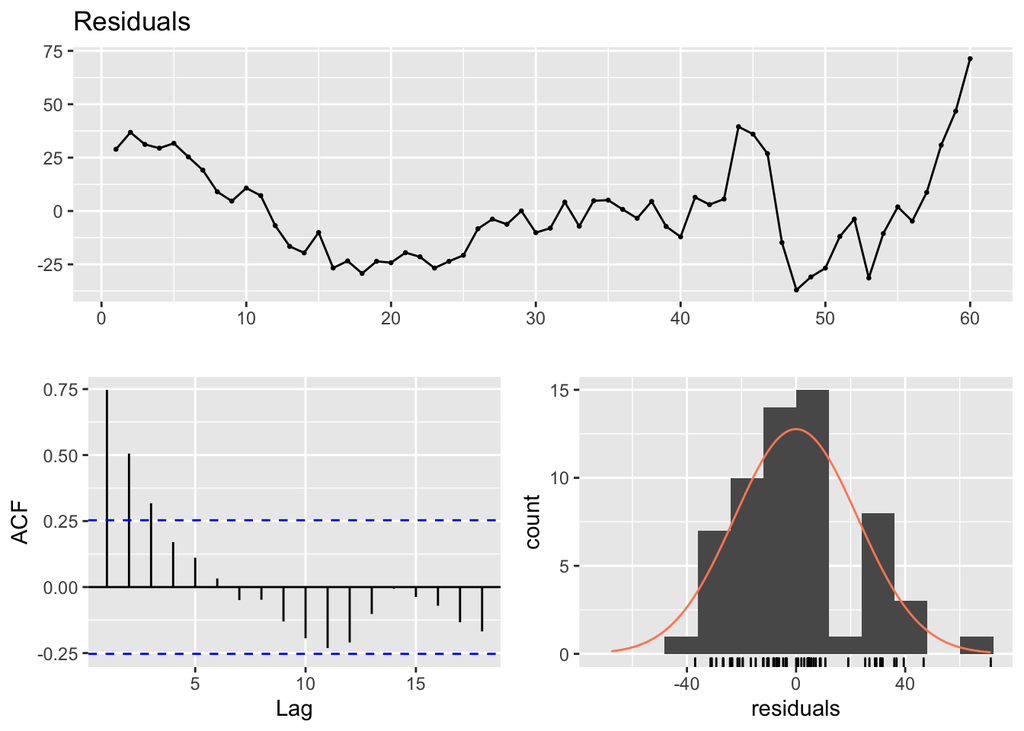

```
##
##  Breusch-Godfrey test for serial correlation of order up to 10
##
## data:  Residuals
## LM test = 43.412, df = 10, p-value = 4.196e-06
```

```r
#checkresiduals() produces a time plot, ACF plot and histogram of the residuals
checkresiduals(m1)
```

From a time plot of residuals(top), we can see that residuals do not exhibit mean-reversion. The histogram of residuals of the linear model(bottom right) has a long right tail (right-skewwed), which suggests that the residuals of the linear model are not normally distrubuted. From the ACF of residuals(bottom left), there exists an significant correlation in the first three lags in the residuals series.

Second, we plot a histogram of the residuals of the log-linear model.

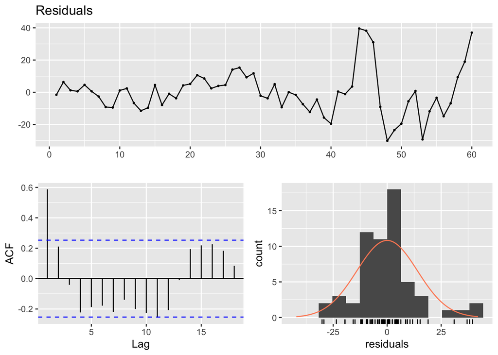

```
##
##  Breusch-Godfrey test for serial correlation of order up to 10
##
## data:  Residuals
## LM test = 32.103, df = 10, p-value = 0.0003849
```

```r
#checkresiduals() produces a time plot, ACF plot and histogram of the residuals
checkresiduals(m2)
```

From a time plot of residuals (top), the range of residuals is much smaller and more close to zero compared to residuals of the linear model. From the ACF of residuals(bottom left), there exists an significant correlation at lag1 in the residuals series and the rest of the lags are within the range (blue dash line). The histogram of residuals of the non-linear model (bottom right) has a long right tail. Compared to the residuals of the linear model, the residuals of the non-linear model appear more normal.

For each model, we will discuss the associated diagnostics tatistics.

```r
#diagnostic statistics
summary(m1)
```

```
##
## Call:
## lm(formula = adj.close ~ t)
##
## Residuals:
##     Min      1Q  Median      3Q     Max
## -36.999 -17.323  -3.804   8.797  71.359
##
## Coefficients:
##               Estimate Std. Error t value Pr(>|t|)
## (Intercept) -57264.867   4040.239  -14.17   <2e-16 ***
## t               28.458      2.003   14.21   <2e-16 ***
## ---
## Signif. codes:  0 '***' 0.001 '**' 0.01 '*' 0.05 '.' 0.1 ' ' 1
##
## Residual standard error: 22.77 on 58 degrees of freedom
## Multiple R-squared:  0.7769, Adjusted R-squared:  0.773
## F-statistic: 201.9 on 1 and 58 DF,  p-value: < 2.2e-16
```

Since $R^2$ is 0.7769, this indicates that 77.69% of AAPL adjusted close price can be explained by this linear model. Given $\alpha$ = 0.05, since t-value is 14.21 that is greater than 1.96, we see that the time variable is statistically significant. Since there is only 1 variable, then F distribution and t distribution are the same. Also, since all p-values are less than the 0.05 threshold, then we can conclude our model is indeed statistically significant.

```r
#diagnostic statistics
summary(m2)
```

```
##
## Call:
## lm(formula = adj.close ~ sin((3/4) * pi * t) + t + I(t^2))
##
## Residuals:
##     Min      1Q  Median      3Q     Max
## -30.158  -8.212  -0.446   4.690  39.590
##
## Coefficients:
##                       Estimate Std. Error t value Pr(>|t|)
## (Intercept)          2.535e+07  3.931e+06   6.449 2.81e-08 ***
## sin((3/4) * pi * t) -1.836e+01  2.792e+00  -6.577 1.73e-08 ***
## t                   -2.516e+04  3.897e+03  -6.457 2.72e-08 ***
## I(t^2)               6.244e+00  9.658e-01   6.465 2.64e-08 ***
## ---
## Signif. codes:  0 '***' 0.001 '**' 0.01 '*' 0.05 '.' 0.1 ' ' 1
##
## Residual standard error: 14.39 on 56 degrees of freedom
## Multiple R-squared:  0.9139, Adjusted R-squared:  0.9093
## F-statistic: 198.2 on 3 and 56 DF,  p-value: < 2.2e-16
```

Now, we take a look at AIC and BIC to select appropriate model

```r
#model selection
AIC(m1,m2)
```

```
##    df      AIC
## m1  3 549.2709
## m2  5 496.1297
```

```r
BIC(m1, m2)
```

```
##    df      BIC
## m1  3 555.5539
## m2  5 506.6014
```

From the tables above, since values of both AIC and BIC of the log-linear model are much smaller than those of the linear model, then both AIC and BIC select the non-linear fit as the preferred model. Therefore, the seleted models agree.

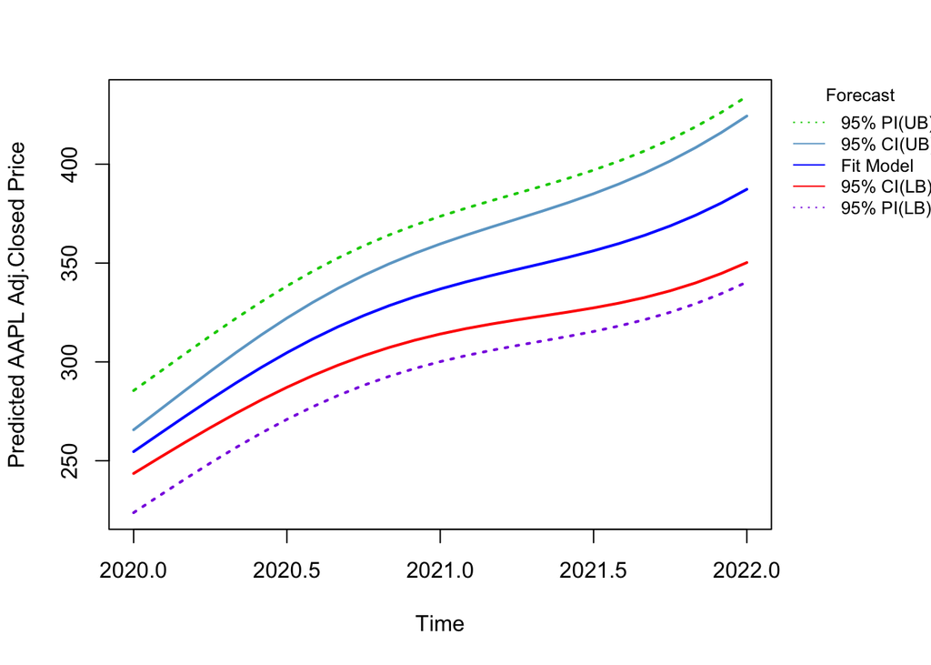

```r
#create a time varaible
tn = data.frame(t = seq(from = 2020.000, to = 2022.000, by = 2/24))
#uncertainty prediction interval at 95% CI
pred.plim = predict((m2), tn,
                    level =0.95, interval="prediction")
#confidence interval at 95% CI
pred.clim = predict((m2), tn,
                    level=0.95, interval="confidence")
#set an outside margin
#xpd = TRUE tells R that it is OK to plot outside the region
par(mar = c(bottom = 5.1, left = 4.1, top = 3, right = 6), xpd=TRUE)
#forecast plot with uncertainty prediction interval
matplot(tn$t,cbind(pred.clim, pred.plim[,-1]),
        lty=c(1,1,1,3,3), type="l", lwd=2,
        ylab="Predicted AAPL Adj.Closed Price",
        col = c("blue", "red", "skyblue3", "blueviolet", "green3"),
        xlab="Time")
#add the legend to the plot
# horiz = FALSE tells R that I need a vertical legend
# bty = "n" means no outside box for the legend
#UB stands for upper bound, LB stands for lower bound
#PI stands for prediction interval
#CI stands for confidence interval
legend("topright", c("95% PI(UB)", "95% CI(UB)", "Fit Model",
                     "95% CI(LB)", "95% PI(LB)"),
       horiz = FALSE, inset=c(-0.26,0), bty = "n",
       col = c("green3", "skyblue3", "blue", "red", "blueviolet"),
       lty=c(3,1,1,1,3), cex = 0.8, title = "Forecast")
```

Note that PI denotes Prediction Interval and CI denotes Confidence Interval.

## Modeling and Forecasting Seasonality

Construct and test (by looking at the diagnostic statistics) a model with a full set of seasonal dummies.

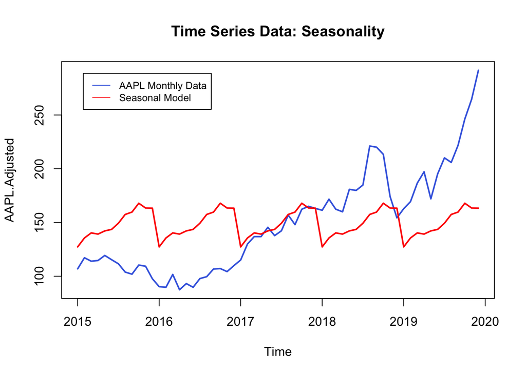

```r
# Construct a model with a full set of seasonal dummies
fit1 = tslm(adj.close ~ season)
# plot the seasonal model
plot(adj.close, main="Time Series Data: Seasonality",
     col = "royalblue", lwd=2)
#add a fitted values line
lines(fit1$fitted.values, col="red", lwd=2)
#add the legend to the plot
legend("topleft", inset = 0.05,
       legend=c("AAPL Monthly Data", "Seasonal Model"),
       col = c("royalblue", "red"), cex = 0.8, lty=1:1)
```

Now, we plot the estimated seasonal factors.

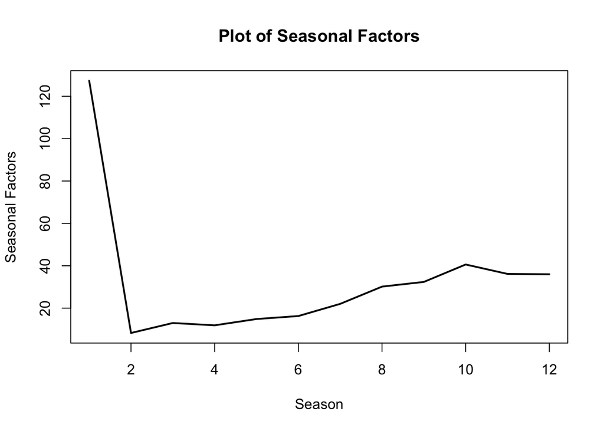

```r
#Plot the estimated seasonal factors
plot(fit1$coef,type='l',ylab='Seasonal Factors', xlab="Season",
     lwd=2, main="Plot of Seasonal Factors")
```

Clealy, there exists low seasonal effects in Feburary. There is a peak in October and a deline in November and December. There exists an increasing trend in seasonal factors effects.

To improve our model, we add the trend model to the seasonal model.

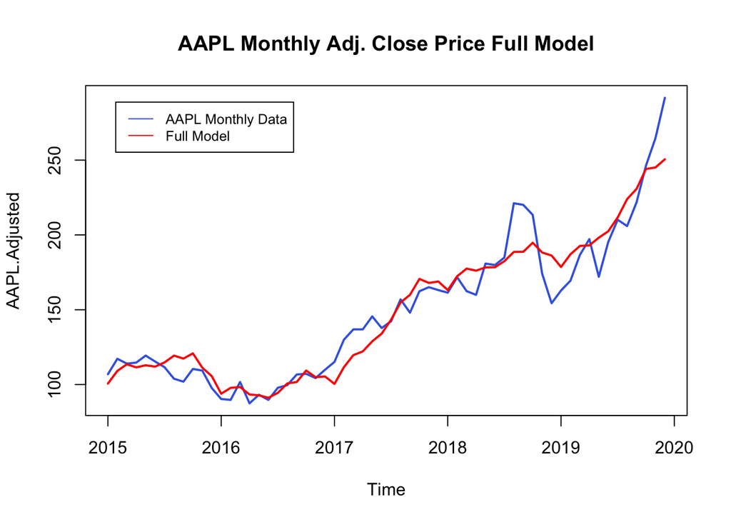

```r
#construct a model with trend and season
fit2 <- tslm(adj.close ~ season + sin((3/4)*pi*time(adj.close)) +
               time(adj.close) + I(time(adj.close)^2))
#plot the trending and seasona; model
plot(adj.close ,main="AAPL Monthly Adj. Close Price Full Model",
     col = "royalblue", lwd=2)
#add a fitted values line
lines(fit2$fitted.values, col="red", lwd=2)
#add the legend to the plot
legend("topleft", inset = 0.05,  col = c("royalblue", "red"),
       legend=c("AAPL Monthly Data", "Full Model"), cex = 0.8, lty=1:1)
```

For the full model, we plot the respective residuals vs. fitted values.

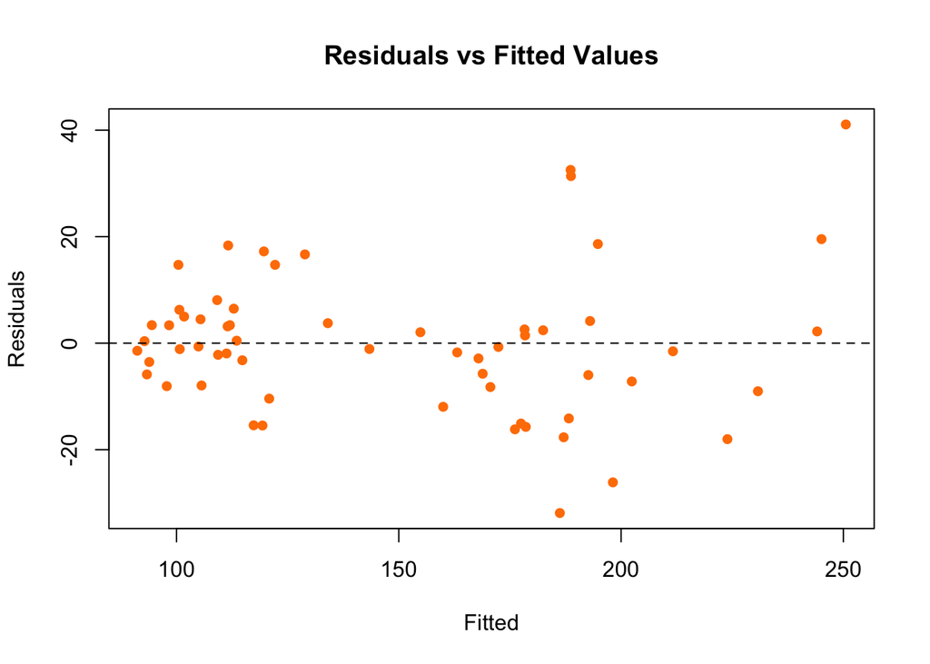

```r
# combine fitted values and residuals columns into one data frame
fit2_new <- as.data.frame(cbind(Fitted = fitted(fit2),
                                Residuals = residuals(fit2)))
#plot the respective residuals vs. fitted values
plot(fit2_new, main = "Residuals vs Fitted Values",
     pch = 16, col = "darkorange1", xlab = "Fitted", ylab = "Residuals")
#add a mean line
abline(h = 0, lty = 2)
```

There are several outliers in the plot. There does not exist clear pattern. The residuals bounce randomly around 0 and there is non-linear relationship between fitted values and residuals, suggesting that this model is appropriate.

We interpret the respective summary statistics including the error metrics of the full model.

```r
#show the summary statistics of the full model
summary(fit2)
```

```
##
## Call:
## tslm(formula = adj.close ~ season + sin((3/4) * pi * time(adj.close)) +
##     time(adj.close) + I(time(adj.close)^2))
##
## Residuals:
##     Min      1Q  Median      3Q     Max
## -31.884  -7.972  -0.897   4.243  41.074
##
## Coefficients:
##                                     Estimate Std. Error t value Pr(>|t|)
## (Intercept)                        2.704e+07  4.330e+06   6.244 1.35e-07
## season2                            6.313e+00  9.697e+00   0.651   0.5183
## season3                            8.999e+00  9.700e+00   0.928   0.3585
## season4                            5.800e+00  9.704e+00   0.598   0.5530
## season5                            6.587e+00  9.709e+00   0.678   0.5010
## season6                            5.718e+00  9.716e+00   0.588   0.5591
## season7                            9.086e+00  9.724e+00   0.934   0.3551
## season8                            1.473e+01  9.732e+00   1.514   0.1370
## season9                            1.433e+01  9.742e+00   1.471   0.1482
## season10                           1.981e+01  9.754e+00   2.031   0.0482
## season11                           1.247e+01  9.766e+00   1.277   0.2080
## season12                           9.286e+00  9.781e+00   0.949   0.3475
## sin((3/4) * pi * time(adj.close)) -1.775e+01  2.961e+00  -5.995 3.18e-07
## time(adj.close)                   -2.684e+04  4.293e+03  -6.252 1.32e-07
## I(time(adj.close)^2)               6.659e+00  1.064e+00   6.259 1.29e-07
##
## (Intercept)                       ***
## season2
## season3
## season4
## season5
## season6
## season7
## season8
## season9
## season10                          *
## season11
## season12
## sin((3/4) * pi * time(adj.close)) ***
## time(adj.close)                   ***
## I(time(adj.close)^2)              ***
## ---
## Signif. codes:  0 '***' 0.001 '**' 0.01 '*' 0.05 '.' 0.1 ' ' 1
##
## Residual standard error: 15.33 on 45 degrees of freedom
## Multiple R-squared:  0.9215, Adjusted R-squared:  0.8971
## F-statistic: 37.73 on 14 and 45 DF,  p-value: < 2.2e-16
```

Since $R^2$ is 0.9215, which means that 92.15% of the original data can be explained by the full model. Compared to the non-linear model in problem 1, the full model explains the AAPL monthly adjusted close prices better. Since the F critical value is 1.92, which is less than F-statistic(37.73), this implies there are at least one coefficient of the full model is not equal to zero. From the table, since p-values of coefficients of season10, $sin((3/4) \pi\cdot time(adj.close))$, $time(adj.close)$ and $I(time(adj.close)^2)$ are less than the 0.05 threshold, then they are statistcally significant.

Now, we analyze the error metrics of our full model.

```r
#produce the error metrics of the full model and compare with the non-linear model
accuracy(fit2)
```

```
##                         ME     RMSE      MAE       MPE     MAPE      MASE
## Training set -1.184411e-15 13.27659 9.598611 -0.498908 6.222146 0.2888429
##                   ACF1
## Training set 0.5616792
```

```r
accuracy(m2)
```

```
##                         ME     RMSE      MAE        MPE     MAPE      MASE
## Training set -1.184411e-15 13.90352 9.835545 -0.5323762 6.273262 0.2501157
```

Then we compare mean sqaured error with the non-linear model in problem 1 and the final model.

```r
#install packages containing mse function
library(mltools)
mse(preds = fit2$fitted.values, actuals = adj.close)
```

```
## [1] 176.2679
```

```r
mse(preds = m2$fitted.values, actuals = adj.close)
```

```
## [1] 193.3079
```

```r
#uncertainty prediction interval at 95% CI
pred.plim2 = predict((fit2), tn,
                     level =0.95, interval="prediction")
#confidence interval at 95% CI
pred.clim2 = predict((fit2), tn,
                     level=0.95, interval="confidence")
```

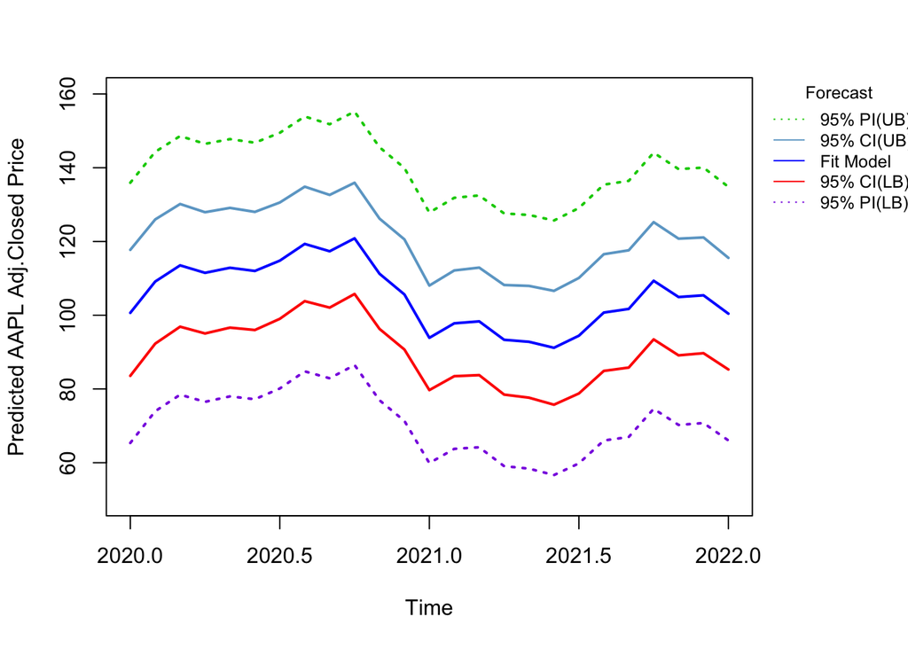

```r
pred.plim3 <- pred.plim2[,-1]
#
est_int <- cbind(pred.clim2[1:25, ], pred.plim3[1:25, ])
#set an outside margin
#xpd = TRUE tells R that it is OK to plot outside the region
par(mar = c(bottom = 5.1, left = 4.1, top = 3, right = 6), xpd=TRUE)
#forecast plot with uncertainty prediction interval
matplot(tn$t, est_int,
        lty=c(1,1,1,3,3), type="l", lwd=2,
        ylab="Predicted AAPL Adj.Closed Price",
        col = c("blue", "red", "skyblue3", "blueviolet", "green3"),
        xlab="Time", xlim = c(2020, 2022), ylim = c(50, 160))
#add the legend to the plot
# horiz = FALSE tells R that I need a vertical legend
# bty = "n" means no outside box for the legend
#UB stands for upper bound, LB stands for lower bound
#PI stands for prediction interval
#CI stands for confidence interval
legend("topright", c("95% PI(UB)", "95% CI(UB)", "Fit Model",
                     "95% CI(LB)", "95% PI(LB)"),
       horiz = FALSE, inset=c(-0.26,0), bty = "n",
       col = c("green3", "skyblue3", "blue", "red", "blueviolet"),
       lty=c(3,1,1,1,3), cex = 0.8, title = "Forecast")
```

## References

George Athanasopoulos, Rob J Hyndman. (2018). Forecasting principles and practice (2nd ed., pp.69-93). Monash University, Australia.